# FinalProject

Madeline Egbert

4/19/2021

```r
library(tidyverse)
library(dplyr)
library(lubridate)
deathsByAge <- readr::read_csv('deaths_by_age_group.csv')

casesByAge <- readr::read_csv('cases_by_age_group.csv')

covid19Data <- readr::read_csv('covid19_vaccinations_in_the_united_states.csv')

casesdeathsByState <- readr::read_csv('united_states_covid19_cases_and_deaths_by_state.csv')
```

```r
deathsByAge
```

```
## # A tibble: 9 x 4
##   `Age Group` `Percentage of deaths` `Count of deaths` `Percent of US populatio…
##   <chr>       <chr>                              <dbl>                     <dbl>
## 1 0-4 Years   <0.1                                 108                       6
## 2 5-17 Years  0.1                                  244                      16.3
## 3 18-29 Years 0.5                                 2063                      16.4
## 4 30-39 Years 1.1                                 4890                      13.5
## 5 40-49 Years 2.8                                12051                      12.3
## 6 50-64 Years 14.6                               62492                      19.2
## 7 65-74 Years 21.4                               91108                       9.6
## 8 75-84 Years 27.7                              118007                       4.9
## 9 85+ Years   31.8                              135707                       2
```

```r
casesByAge
```

```
## # A tibble: 9 x 4
##   `Age Group` `Percent of cases` `Count of cases` `Percent of US population`
##   <chr>                    <dbl>            <dbl>                      <dbl>
## 1 0-4 Years                  2             476372                        6
## 2 5-17 Years                 9.8          2324060                       16.3
## 3 18-29 Years               22.4          5320608                       16.4
## 4 30-39 Years               16.4          3888891                       13.5
## 5 40-49 Years               14.9          3543373                       12.3
## 6 50-64 Years               20.5          4881153                       19.2
## 7 65-74 Years                7.7          1830176                        9.6
## 8 75-84 Years                4             956408                        4.9
## 9 85+ Years                  2.4           560301                        2
```

```r
covid19Data
```

```
## # A tibble: 63 x 51
##    `State/Territor… `Total Doses De… `Doses Delivere… `18+ Doses Deli…
##    <chr>                       <dbl> <chr>            <chr>
##  1 Alaska                     658125 89964            119320
##  2 Alabama                   3106870 63364            81441
##  3 Arkansas                  1977830 65539            85338
##  4 American Samoa              43810 78669            100859
##  5 Arizona                   4762745 65434            84469
##  6 Bureau of Priso…           123170 N/A              N/A
##  7 California               26977640 68277            88112
##  8 Colorado                  3720990 64615            82703
##  9 Connecticut               2805115 78679            98847
## 10 District of Col…           562645 79723            97414
## # … with 53 more rows, and 47 more variables: `Total Doses Administered by
## #   State where Administered` <dbl>, `Doses Administered per 100k by State
## #   where Administered` <chr>, `18+ Doses Administered by State where
## #   Administered` <dbl>, `18+ Doses Administered per 100K by State where
## #   Administered` <chr>, `People with at least One Dose by State of
## #   Residence` <dbl>, `Percent of Total Pop with at least One Dose by State of
## #   Residence` <chr>, `People 18+ with at least One Dose by State of
## #   Residence` <dbl>, `Percent of 18+ Pop with at least One Dose by State of
## #   Residence` <chr>, `People Fully Vaccinated by State of Residence` <dbl>,
## #   `Percent of Total Pop Fully Vaccinated by State of Residence` <chr>,
## #   `People 18+ Fully Vaccinated by State of Residence` <dbl>, `Percent of 18+
## #   Pop Fully Vaccinated by State of Residence` <chr>, `Total Number of Pfizer
## #   doses delivered` <dbl>, `Total Number of Moderna doses delivered` <dbl>,
## #   `Total Number of Janssen doses delivered` <dbl>, `Total Number of doses
## #   from unknown manufacturer delivered` <dbl>, `Total Number of Janssen doses
## #   administered` <dbl>, `Total Number of Moderna doses administered` <dbl>,
## #   `Total Number of Pfizer doses adminstered` <dbl>, `Total Number of doses
## #   from unknown manufacturer administered` <dbl>, `People Fully Vaccinated
## #   Moderna Resident` <dbl>, `People Fully Vaccinated Pfizer Resident` <dbl>,
## #   `People Fully Vaccinated Janssen Resident` <dbl>, `People Fully Vaccinated
## #   Unknown 2-dose manufacturer Resident` <dbl>, `People 18+ Fully Vaccinated
## #   Moderna Resident` <dbl>, `People 18+ Fully Vaccinated Pfizer
## #   Resident` <dbl>, `People 18+ Fully Vaccinated Janssen Resident` <dbl>,
## #   `People 18+ Fully Vaccinated Unknown 2-dose manufacturer Resident` <dbl>,
## #   `People with 2 Doses by State of Residence` <dbl>, `Percent of Total Pop
## #   with 1+ Doses by State of Residence` <chr>, `People 18+ with 1+ Doses by
## #   State of Residence` <dbl>, `Percent of 18+ Pop with 1+ Doses by State of
## #   Residence` <chr>, `Percent of Total Pop with 2 Doses by State of
## #   Residence` <dbl>, `People 18+ with 2 Doses by State of Residence` <dbl>,
## #   `Percent of 18+ Pop with 2 Doses by State of Residence` <dbl>, `People with
## #   1+ Doses by State of Residence` <dbl>, `People 65+ with at least One Dose
## #   by State of Residence` <dbl>, `Percent of 65+ Pop with at least One Dose by
## #   State of Residence` <dbl>, `People 65+ Fully Vaccinated by State of
## #   Residence` <dbl>, `Percent of 65+ Pop Fully Vaccinated by State of
## #   Residence` <dbl>, `People 65+ Fully Vaccinated_Moderna_Resident` <dbl>,
## #   `People 65+ Fully Vaccinated_Pfizer_Resident` <dbl>, `People 65+ Fully
## #   Vaccinated_Janssen_Resident` <dbl>, `People 65+ Fully Vaccinated_Unknown
## #   2-dose Manuf_Resident` <dbl>, `65+ Doses Administered by State where
## #   Administered` <dbl>, `Doses Administered per 100k of 65+ pop by State where
## #   Administered` <dbl>, `Doses Delivered per 100k of 65+ pop` <dbl>
```

```r
str(covid19Data)
```

[output not shown]

[output cut: 51 more lines]

```
##   ..   `People 18+ with 2 Doses by State of Residence` = col_double(),
##   ..   `Percent of 18+ Pop with 2 Doses by State of Residence` = col_double(),
##   ..   `People with 1+ Doses by State of Residence` = col_double(),
##   ..   `People 65+ with at least One Dose by State of Residence` = col_double(),
##   ..   `Percent of 65+ Pop with at least One Dose by State of Residence` = col_double(),
##   ..   `People 65+ Fully Vaccinated by State of Residence` = col_double(),
##   ..   `Percent of 65+ Pop Fully Vaccinated by State of Residence` = col_double(),
##   ..   `People 65+ Fully Vaccinated_Moderna_Resident` = col_double(),
##   ..   `People 65+ Fully Vaccinated_Pfizer_Resident` = col_double(),
##   ..   `People 65+ Fully Vaccinated_Janssen_Resident` = col_double(),
##   ..   `People 65+ Fully Vaccinated_Unknown 2-dose Manuf_Resident` = col_double(),
##   ..   `65+ Doses Administered by State where Administered` = col_double(),
##   ..   `Doses Administered per 100k of 65+ pop by State where Administered` = col_double(),
##   ..   `Doses Delivered per 100k of 65+ pop` = col_double()
##   .. )
```

#What states had the highest increase in cases over the span of a week?

```r
mostcases7days <- casesdeathsByState %>%
   rename(State = `State/Territory`, ) %>%
  filter(State != 'United States of America', State != 'New York City') %>%
  select(State, `Cases in Last 7 Days`) %>%
  top_n(10, `Cases in Last 7 Days`)

str(mostcases7days)
```

```
## tibble [10 × 2] (S3: tbl_df/tbl/data.frame)
##  $ State               : chr [1:10] "California" "Florida" "Illinois" "Massachusetts" ...
##  $ Cases in Last 7 Days: num [1:10] 17995 36872 19147 13725 47036 ...
```

```r
casesweek <- mostcases7days %>%
  group_by(State) %>%
  summarize(`Cases in Last 7 Days` = max(`Cases in Last 7 Days`)) %>%
  arrange(desc(`Cases in Last 7 Days`)) %>%
  head(n=5)

head(casesweek)
```

```
## # A tibble: 5 x 2
##   State        `Cases in Last 7 Days`
##   <chr>                         <dbl>
## 1 Michigan                      47036
## 2 Florida                       36872
## 3 Pennsylvania                  30132
## 4 New Jersey                    29753
## 5 New York                      27496
```

#explanation: The top 5 states with the most cases in the span of a week are as follows: Michigan, Florida, Pennsylvania, New Jersey and New York. Michigan has 10,164 more cases in a week than Florida which is decently large spike in Michigan.

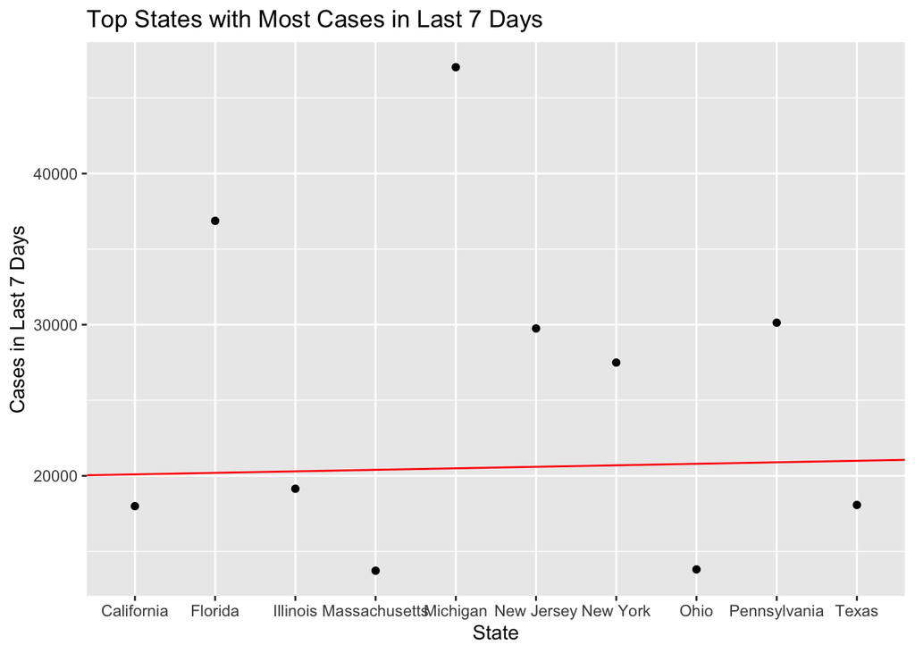

```r
topcases7days <- ggplot(mostcases7days, aes(x=State, y=`Cases in Last 7 Days`)) + geom_point() + ggtitle('Top States with Most Cases in Last 7 Days') + xlab('State') + ylab('Cases in Last 7 Days')

topcases7days + geom_abline(intercept = 20000, slope = 100, color = "red")
```

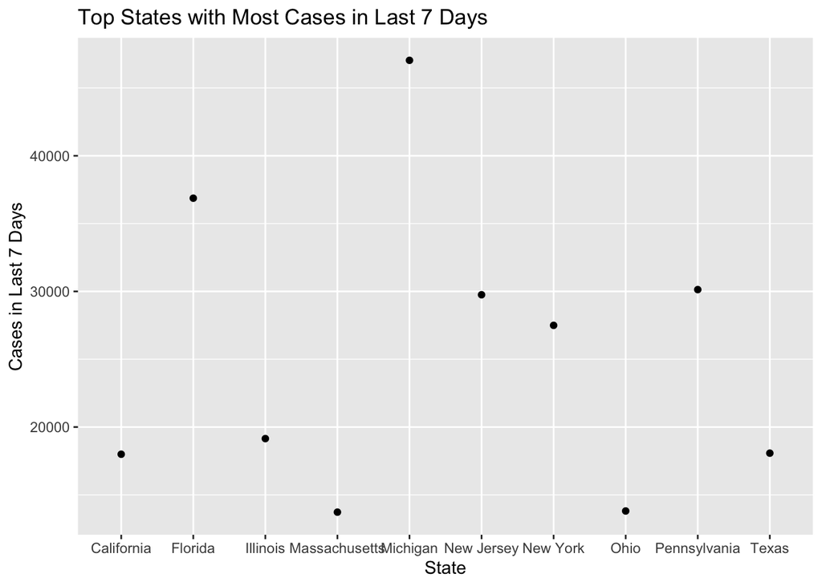

```r
CasesCount <- ggplot(mostcases7days, aes(x=State, y= `Cases in Last 7 Days`)) + geom_point() + ggtitle('Top States with Most Cases in Last 7 Days') + xlab('State') + ylab('Cases in Last 7 Days')

CasesCount + geom_abline(intercept = 100, slope = 50, color = "Purple")
```

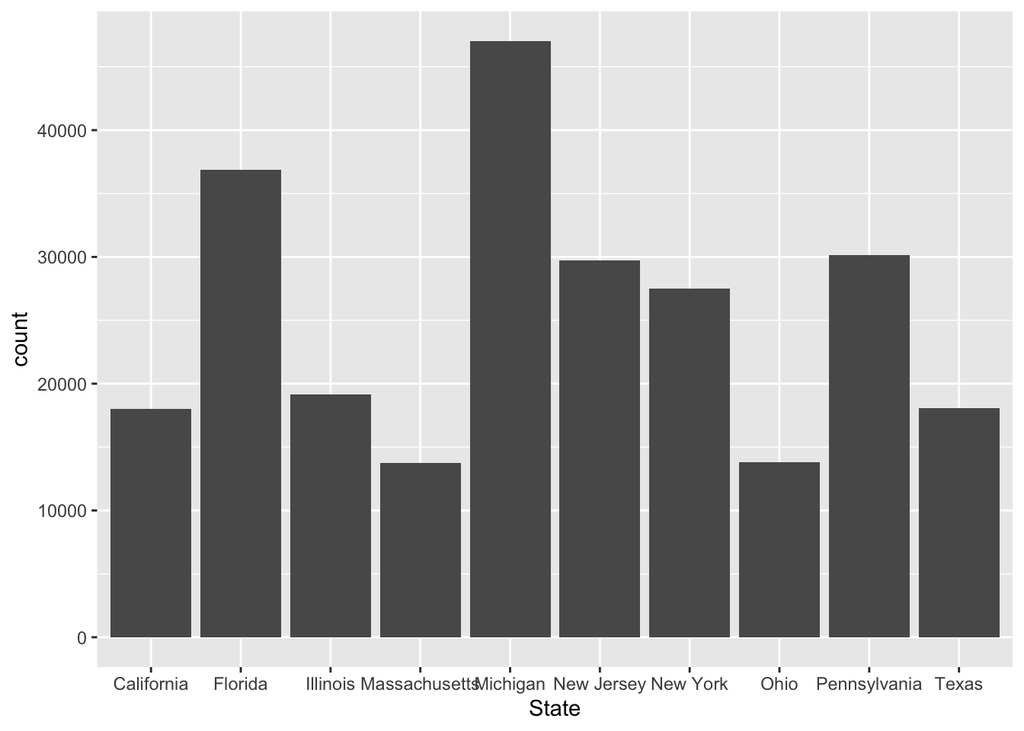

```r
ggplot(mostcases7days, aes(x= State, weight = `Cases in Last 7 Days`)) + geom_bar()
```

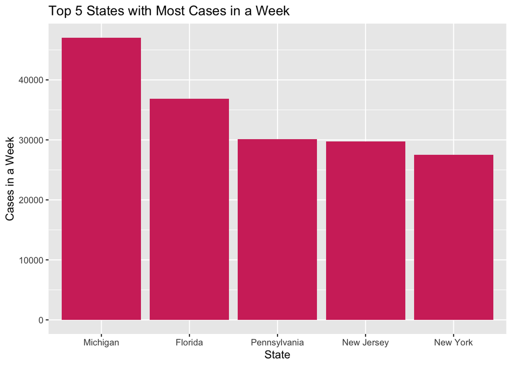

```r
ggplot(mostcases7days, aes(x=State, weight = `Cases in Last 7 Days`)) + geom_bar(fill = '#D23369') + scale_x_discrete(limit = c('Michigan', 'Florida', 'Pennsylvania', 'New Jersey', 'New York')) + ggtitle('Top 5 States with Most Cases in a Week') + xlab('State') + ylab('Cases in a Week')
```

#explanation: according to the results of the above graph,the top 5 states with the most cases recorded within the span of a week include: Michigan, Florida, Pennsylvania, New Jersey, and New York. I am suprised to not see California in the top 5 because of how large the state is and how populated it is as well.

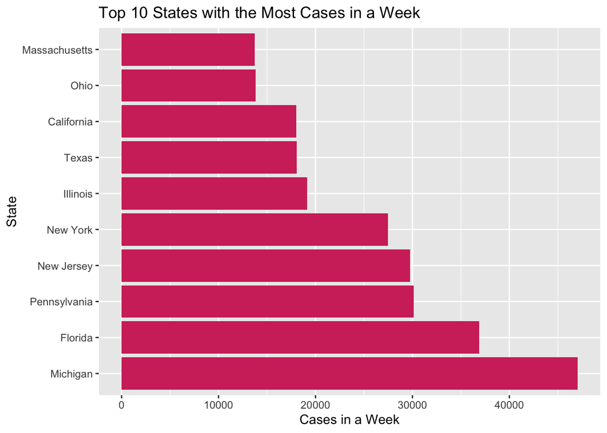

```r
ggplot(mostcases7days, aes(x = State, weight = `Cases in Last 7 Days`)) + geom_bar(fill = '#D23369') + scale_x_discrete(limit = c('Michigan', 'Florida', 'Pennsylvania', 'New Jersey', 'New York', 'Illinois', 'Texas', 'California', 'Ohio', 'Massachusetts')) + ggtitle('Top 10 States with the Most Cases in a Week') + xlab('State') + ylab('Cases in a Week') + coord_flip()
```